# BrightnessContrast QML Type

Adjusts brightness and contrast. More...

| Import Statement: | `import Qt5Compat.GraphicalEffects` |
| --- | --- |
| Since: | QtGraphicalEffects 1.0 |
| Inherits: | Item |

- [List of all members, including inherited members](https://doc.qt.io/qt-6.9/qml-qt5compat-graphicaleffects-brightnesscontrast-members.html)

## Properties

- **brightness** : real
- **cached** : bool
- **contrast** : real
- **source** : variant

## Detailed Description

This effect adjusts the source item colors. Brightness adjustment changes the perceived luminance of the source item. Contrast adjustment increases or decreases the color and brightness variations.

Effect applied

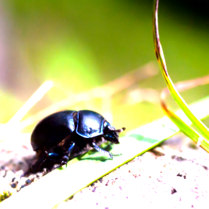

## Example

The following example shows how to apply the effect.

```
import QtQuick
import Qt5Compat.GraphicalEffects

Item {
    width: 300
    height: 300

    Image {
        id: bug
        source: "images/bug.jpg"
        sourceSize: Qt.size(parent.width, parent.height)
        smooth: true
        visible: false
    }

    BrightnessContrast {
        anchors.fill: bug
        source: bug
        brightness: 0.5
        contrast: 0.5
    }
}
```

## Property Documentation

### brightness : real

This property defines how much the source brightness is increased or decreased.

The value ranges from -1.0 to 1.0. By default, the property is set to `0.0` (no change).

Output examples with different brightness values

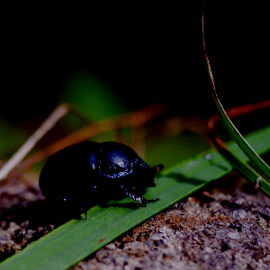

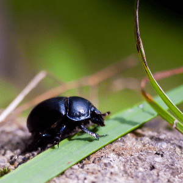

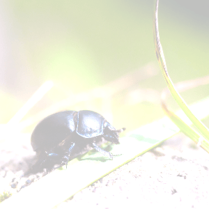

**brightness: -0.25**

**brightness: 0**

**brightness: 0.5**

contrast: 0

contrast: 0

contrast: 0

### cached : bool

This property allows the effect output pixels to be cached in order to improve the rendering performance.

Every time the source or effect properties are changed, the pixels in the cache must be updated. Memory consumption is increased, because an extra buffer of memory is required for storing the effect output.

It is recommended to disable the cache when the source or the effect properties are animated.

By default, the property is set to `false`.

### contrast : real

This property defines how much the source contrast is increased or decreased. The decrease of the contrast is linear, but the increase is applied with a non-linear curve to allow very high contrast adjustment at the high end of the value range.

Contrast adjustment curve

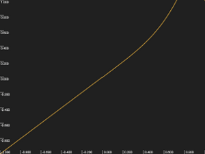

The value ranges from -1.0 to 1.0. By default, the property is set to `0.0` (no change).

Output examples with different contrast values

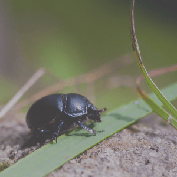

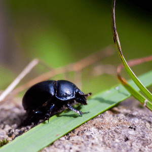

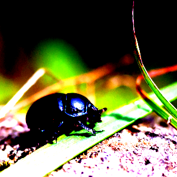

**contrast: -0.5**

**contrast: 0**

**contrast: 0.5**

brightness: 0

brightness: 0

brightness: 0

### source : variant

This property defines the source item that provides the source pixels for the effect.

**Note:** It is not supported to let the effect include itself, for instance by setting source to the effect's parent.

© The Qt Company Ltd  
Licensed under the GNU Free Documentation License, Version 1.3.  
https://doc.qt.io/qt-6.9/qml-qt5compat-graphicaleffects-brightnesscontrast.html